# Verzani Problem Set

### Problem 5.2

The Simple data set `chips` contains data on thickness of integrated chips. There are data for two chips, each measured at $4$ different places. Create a side-by-side boxplot of the thickness for each place of measurement. (There should be $8$ boxplots on the same graph). Do the means look the same? The variances?

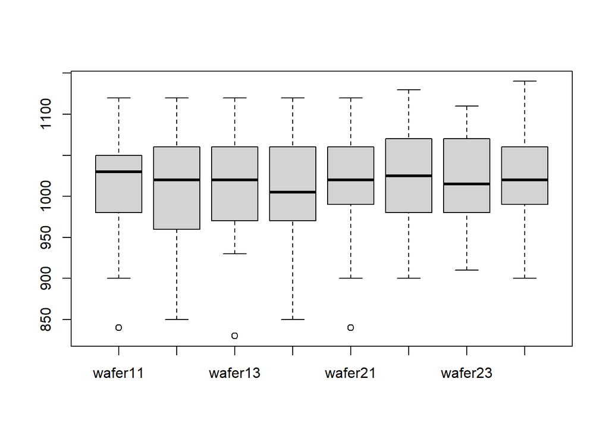

```r
> chips
   wafer11 wafer12 wafer13 wafer14 wafer21 wafer22 wafer23 wafer24
1      950     930     950     930    1010     980     970     980
2     1050    1050    1030    1040    1050    1050    1050    1060
3      940     960     940     930    1000     980     960    1020
4      990    1020    1020    1000     980     990    1000     990
5      980     980     980    1000     900     920     910     940
6      900     940     930     930     930     930     960     900
7     1050    1070    1100    1070    1110    1130    1100    1140
8     1100    1060    1070    1050    1070    1090    1110    1060
9     1070    1030    1070    1020    1020    1070    1090    1050
10    1000     950    1010     970    1020     980     990    1020
11    1050    1060    1040    1050    1060    1030    1010     980
12    1050    1060    1060    1060    1060    1070    1050    1060
13    1050    1010    1080    1090    1010    1040     980    1010
14    1070    1080    1070    1060    1020    1020    1040    1040
15    1000     950     960     970     980    1000    1010    1020
16     990     990    1020     990    1000    1010    1000    1010
17    1120    1080    1110    1120    1100    1090    1070    1120
18     930     950     930     920     990    1000    1010    1000
19     960     960     940     980    1020    1050    1060    1040
20     970     990    1040    1000    1000    1040     980    1010
21    1100    1120    1120    1080    1060    1070    1090    1050
22    1040    1020    1040    1050    1120    1100    1080    1090
23    1030    1050    1010    1060    1010    1000    1020    1030
24    1030    1020    1000    1010    1100    1120    1110    1080
25    1010    1030     970    1000    1030    1110    1030    1060
26    1000     960     970     960    1090    1120    1080    1100
27    1100    1060    1040    1080    1020    1000    1020     990
28    1030     990    1020     980     920     920     970     910
29     840     850     830     850     840     900     910     900
30    1040    1060    1060    1070     960     930     950     980
> boxplot(chips)
```

### Problem 5.3

The Simple data set `chicken` contains weights of chickens who are given $1$ of $3$ different food rations. Create a boxplot of all $3$ rations. Does there appear to be a difference in mean?

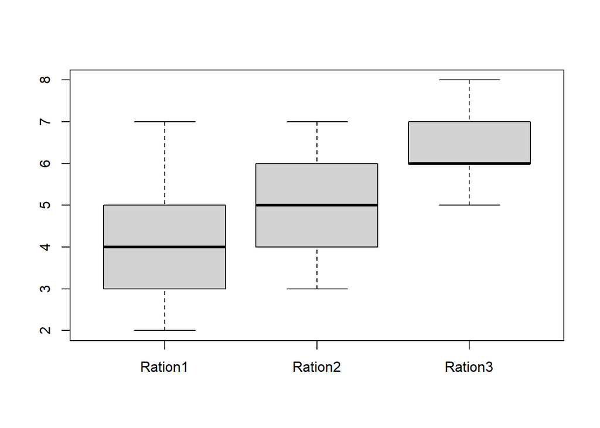

```r
> chicken
   Ration1 Ration2 Ration3
1        4       3       6
2        4       4       7
3        7       5       7
4        3       4       7
5        2       6       6
6        5       4       8
7        4       5       5
8        5       6       6
9        2       7       7
10       3       6       6
11       6       5       7
12       4       5       5
13       5       5       6
> boxplot(chicken)
```

### Problem 5.5

The Simple data set `carbon` contains carbon monoxide levels at $3$ different industrial sites. The data has two variables: a carbon monoxide reading, and a factor variable to keep track of the site. Create side-by-side boxplots of the monoxide levels for each site. Does there appear to be a difference? How so?

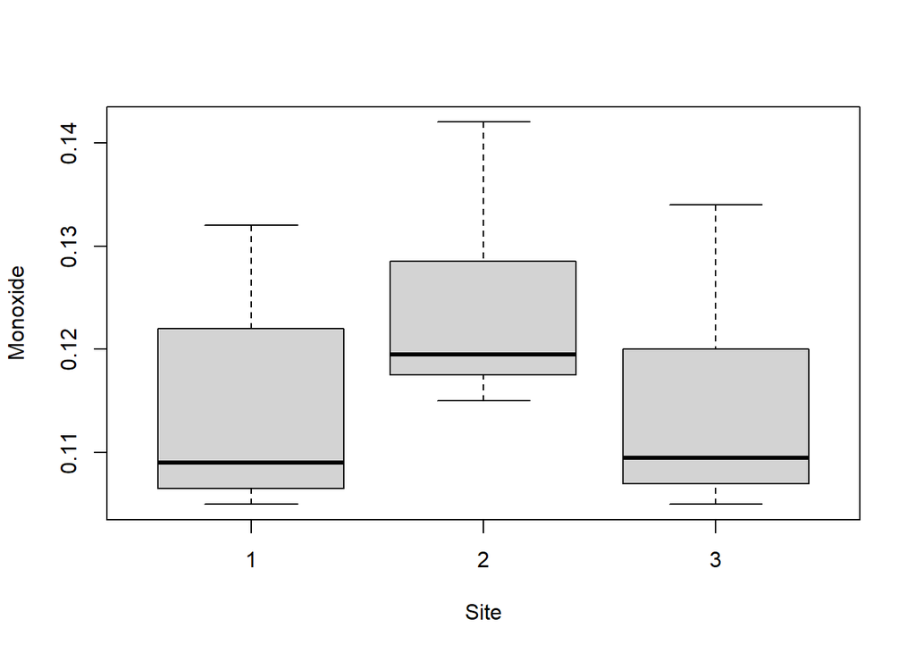

```r
> carbon
   Monoxide Site
1     0.106    1
2     0.127    1
3     0.132    1
4     0.105    1
5     0.117    1
6     0.109    1
7     0.107    1
8     0.109    1
9     0.122    2
10    0.119    2
11    0.115    2
12    0.120    2
13    0.117    2
14    0.135    2
15    0.118    2
16    0.142    2
17    0.119    3
18    0.110    3
19    0.106    3
20    0.108    3
21    0.105    3
22    0.121    3
23    0.109    3
24    0.134    3
> boxplot(Monoxide ~ Site, data = carbon)
```

### Problem 5.6

[figure not shown]

```r
> head(babies)
   id pluralty outcome date gestation sex  wt parity race age ed ht wt1 drace
1  15        5       1 1411       284   1 120      1    8  27  5 62 100     8
2  20        5       1 1499       282   1 113      2    0  33  5 64 135     0
3  58        5       1 1576       279   1 128      1    0  28  2 64 115     5
4  61        5       1 1504       999   1 123      2    0  36  5 69 190     3
5  72        5       1 1425       282   1 108      1    0  23  5 67 125     0
6 100        5       1 1673       286   1 136      4    0  25  2 62  93     3
  dage ded dht dwt marital inc smoke time number
1   31   5  65 110       1   1     0    0      0
2   38   5  70 148       1   4     0    0      0
3   32   1  99 999       1   2     1    1      1
4   43   4  68 197       1   8     3    5      5
5   24   5  99 999       1   1     1    1      5
6   28   2  64 130       1   4     2    2      2
> summary(babies)
       id          pluralty    outcome       date        gestation
 Min.   :  15   Min.   :5   Min.   :1   Min.   :1350   Min.   :148.0
 1st Qu.:5286   1st Qu.:5   1st Qu.:1   1st Qu.:1444   1st Qu.:272.0
 Median :6730   Median :5   Median :1   Median :1540   Median :280.0
 Mean   :6001   Mean   :5   Mean   :1   Mean   :1536   Mean   :286.9
 3rd Qu.:7583   3rd Qu.:5   3rd Qu.:1   3rd Qu.:1627   3rd Qu.:288.0
 Max.   :9263   Max.   :5   Max.   :1   Max.   :1714   Max.   :999.0
      sex          wt            parity            race             age
 Min.   :1   Min.   : 55.0   Min.   : 0.000   Min.   : 0.000   Min.   :15.00
 1st Qu.:1   1st Qu.:108.8   1st Qu.: 0.000   1st Qu.: 0.000   1st Qu.:23.00
 Median :1   Median :120.0   Median : 1.000   Median : 3.000   Median :26.00
 Mean   :1   Mean   :119.6   Mean   : 1.932   Mean   : 3.206   Mean   :27.37
 3rd Qu.:1   3rd Qu.:131.0   3rd Qu.: 3.000   3rd Qu.: 7.000   3rd Qu.:31.00
 Max.   :1   Max.   :176.0   Max.   :13.000   Max.   :99.000   Max.   :99.00
       ed              ht             wt1          drace             dage
 Min.   :0.000   Min.   :53.00   Min.   : 87   Min.   : 0.000   Min.   :18.00
 1st Qu.:2.000   1st Qu.:62.00   1st Qu.:115   1st Qu.: 0.000   1st Qu.:25.00
 Median :2.000   Median :64.00   Median :126   Median : 3.000   Median :29.00
 Mean   :2.922   Mean   :64.67   Mean   :154   Mean   : 3.665   Mean   :30.74
 3rd Qu.:4.000   3rd Qu.:66.00   3rd Qu.:140   3rd Qu.: 7.000   3rd Qu.:35.00
 Max.   :9.000   Max.   :99.00   Max.   :999   Max.   :99.000   Max.   :99.00
      ded             dht             dwt           marital
 Min.   :0.000   Min.   :60.00   Min.   :110.0   Min.   :0.000
 1st Qu.:2.000   1st Qu.:70.00   1st Qu.:165.0   1st Qu.:1.000
 Median :4.000   Median :73.00   Median :190.0   Median :1.000
 Mean   :3.189   Mean   :81.67   Mean   :505.4   Mean   :1.038
 3rd Qu.:5.000   3rd Qu.:99.00   3rd Qu.:999.0   3rd Qu.:1.000
 Max.   :9.000   Max.   :99.00   Max.   :999.0   Max.   :5.000
      inc            smoke             time            number
 Min.   : 0.00   Min.   :0.0000   Min.   : 0.000   Min.   : 0.000
 1st Qu.: 2.00   1st Qu.:0.0000   1st Qu.: 0.000   1st Qu.: 0.000
 Median : 4.00   Median :1.0000   Median : 1.000   Median : 1.000
 Mean   :13.16   Mean   :0.8681   Mean   : 1.748   Mean   : 2.604
 3rd Qu.: 7.00   3rd Qu.:1.0000   3rd Qu.: 1.000   3rd Qu.: 3.000
 Max.   :98.00   Max.   :9.0000   Max.   :99.000   Max.   :98.000
> cor(babies[-c(1, 2, 3, 6)])
                  date     gestation           wt       parity         race
date       1.000000000 -0.0370893281  0.052054933  0.061025303  0.052589926
gestation -0.037089328  1.0000000000  0.062503538  0.028360507 -0.028745804
wt         0.052054933  0.0625035380  1.000000000  0.029619676 -0.112218917
parity     0.061025303  0.0283605066  0.029619676  1.000000000  0.091469758
race       0.052589926 -0.0287458041 -0.112218917  0.091469758  1.000000000
age        0.009044386 -0.0032647549  0.029040643  0.463616156  0.008723863
ed        -0.060371504 -0.0006527895  0.035054105 -0.206769802 -0.048342005
ht        -0.050995255  0.0659813542  0.125541269  0.017379533 -0.081957881
wt1       -0.041230191  0.0494587600  0.046764144  0.059716966  0.024508774
drace     -0.053046616 -0.0144871020 -0.014191908  0.068158246  0.203032554
dage       0.024856736 -0.0109685723  0.014716298  0.376043347  0.061222506
ded       -0.067974099 -0.0047827067  0.027930956 -0.147478881 -0.078975369
dht       -0.221974758 -0.0016026591  0.021517914 -0.038726678 -0.090155948
dwt       -0.232786779 -0.0009432344  0.012860901 -0.026519780 -0.066917697
marital   -0.009675784 -0.0095081684 -0.042107030 -0.051157116  0.066030923
inc        0.012302240 -0.0214020005  0.053010789 -0.032297714  0.049928465
smoke     -0.029985364  0.0190325665  0.006225805 -0.001469149 -0.056110158
time      -0.026934591  0.0031309737  0.034948923  0.049604082 -0.004467052
number    -0.030971628 -0.0041909644 -0.005066123  0.048002090 -0.013549321
                   age            ed            ht           wt1        drace
date       0.009044386 -0.0603715042 -0.0509952552 -0.0412301914 -0.053046616
gestation -0.003264755 -0.0006527895  0.0659813542  0.0494587600 -0.014487102
wt         0.029040643  0.0350541046  0.1255412695  0.0467641440 -0.014191908
parity     0.463616156 -0.2067698023  0.0173795327  0.0597169663  0.068158246
race       0.008723863 -0.0483420049 -0.0819578807  0.0245087740  0.203032554
age        1.000000000  0.1213900095  0.0485180505  0.0627317151  0.009547469
ed         0.121390010  1.0000000000  0.0500080036 -0.0391898656 -0.031007025
ht         0.048518050  0.0500080036  1.0000000000  0.6010032760 -0.030932642
wt1        0.062731715 -0.0391898656  0.6010032760  1.0000000000  0.013645412
drace      0.009547469 -0.0310070251 -0.0309326421  0.0136454115  1.000000000
dage       0.618142590  0.0644345309 -0.0255243978  0.0299923217  0.023826623
ded        0.092213330  0.5449081422  0.0510869552 -0.0168451860 -0.074287909
dht       -0.054654366  0.0481984779  0.0246194183  0.0340865691 -0.072912847
dwt       -0.046529771  0.0260854923  0.0100074472  0.0412411346 -0.057864062
marital   -0.015178817  0.0163951320 -0.0082562207  0.0125507967  0.031141387
inc       -0.058986421 -0.0817256276 -0.0315535819 -0.0123573381  0.013897214
smoke      0.027021219 -0.0022733980  0.0249118119 -0.0099317486 -0.028366883
time       0.045797136 -0.0230294668  0.0001280229 -0.0103630439  0.006155889
number     0.029396366 -0.0455078159  0.0169013644 -0.0002947303 -0.001932597
                  dage          ded          dht           dwt      marital
date       0.024856736 -0.067974099 -0.221974758 -0.2327867790 -0.009675784
gestation -0.010968572 -0.004782707 -0.001602659 -0.0009432344 -0.009508168
wt         0.014716298  0.027930956  0.021517914  0.0128609007 -0.042107030
parity     0.376043347 -0.147478881 -0.038726678 -0.0265197803 -0.051157116
race       0.061222506 -0.078975369 -0.090155948 -0.0669176966  0.066030923
age        0.618142590  0.092213330 -0.054654366 -0.0465297713 -0.015178817
ed         0.064434531  0.544908142  0.048198478  0.0260854923  0.016395132
ht        -0.025524398  0.051086955  0.024619418  0.0100074472 -0.008256221
wt1        0.029992322 -0.016845186  0.034086569  0.0412411346  0.012550797
drace      0.023826623 -0.074287909 -0.072912847 -0.0578640621  0.031141387
dage       1.000000000  0.068797765 -0.040089602 -0.0138952306  0.185793102
ded        0.068797765  1.000000000  0.068497918  0.0583884324  0.062969117
dht       -0.040089602  0.068497918  1.000000000  0.9618183801  0.072143941
dwt       -0.013895231  0.058388432  0.961818380  1.0000000000  0.080966239
marital    0.185793102  0.062969117  0.072143941  0.0809662386  1.000000000
inc       -0.044502750 -0.035745869  0.013988690  0.0063697493  0.048019116
smoke      0.015211773  0.044901102  0.010421539  0.0111606405  0.002560087
time       0.027579833  0.016101824  0.016229967  0.0157323175 -0.011310103
number     0.008498721  0.007191289  0.031676204  0.0283452318 -0.004294144
                   inc        smoke          time        number
date       0.012302240 -0.029985364 -0.0269345913 -0.0309716278
gestation -0.021402001  0.019032566  0.0031309737 -0.0041909644
wt         0.053010789  0.006225805  0.0349489225 -0.0050661228
parity    -0.032297714 -0.001469149  0.0496040818  0.0480020904
race       0.049928465 -0.056110158 -0.0044670515 -0.0135493207
age       -0.058986421  0.027021219  0.0457971355  0.0293963659
ed        -0.081725628 -0.002273398 -0.0230294668 -0.0455078159
ht        -0.031553582  0.024911812  0.0001280229  0.0169013644
wt1       -0.012357338 -0.009931749 -0.0103630439 -0.0002947303
drace      0.013897214 -0.028366883  0.0061558893 -0.0019325975
dage      -0.044502750  0.015211773  0.0275798333  0.0084987208
ded       -0.035745869  0.044901102  0.0161018245  0.0071912886
dht        0.013988690  0.010421539  0.0162299672  0.0316762042
dwt        0.006369749  0.011160640  0.0157323175  0.0283452318
marital    0.048019116  0.002560087 -0.0113101030 -0.0042941445
inc        1.000000000  0.001843584 -0.0026568043  0.0051524186
smoke      0.001843584  1.000000000  0.7367668275  0.7150216090
time      -0.002656804  0.736766827  1.0000000000  0.9726785305
number     0.005152419  0.715021609  0.9726785305  1.0000000000
> pairs(babies[-c(1, 2, 3, 6)])
```

[figure not shown]

```r
> pairs(babies[-c(1, 2, 3, 6)],
+       upper.panel = panel.cor <- function(x, y, ...) {
+         par(usr = c(0, 1, 0, 1))
+         txt <- as.character(format(cor(x, y), digits = 2))
+         text(0.5, 0.5, txt, cex = 6 * abs(cor(x, y)))})
```